# 1 K-Means Clustering_Unsupervised ML Algo

## K-Means Clustering with Scikit-Learn

K-means clustering is one of the most widely used unsupervised machine learning algorithms that forms clusters of data based on the similarity between data instances. For this particular algorithm to work, the number of clusters has to be defined beforehand. The K in the K-means refers to the number of clusters.

The K-means algorithm starts by randomly choosing a centroid value for each cluster. After that the algorithm iteratively performs three steps:

(i) Find the Euclidean distance between each data instance and centroids of all the clusters;

(ii) Assign the data instances to the cluster of the centroid with nearest distance;

(iii) Calculate new centroid values based on the mean values of the coordinates of all the data instances from the corresponding cluster.

## A Simple Example

Let's try to see how the K-means algorithm works with the help of a handcrafted example, before implementing the algorithm in Scikit-Learn.

We have a set of the following two dimensional data instances named D.

```python
D = {(5, 3), (10, 15), (15, 12), (24, 10), (30, 45),
     (85, 70), (71, 80), (60, 78), (55, 52), (80, 91)}

# We want to divide this data into two clusters,
# C1 and C2 based on the similarity between the data points.
D
```

The first step is to randomly initialize values for the centroids of both clusters. Let's name centroids of clusters C1 and C2 as c1 and c2 and initialize them with the values of the first two data points i.e. (5, 3) and (10, 15).

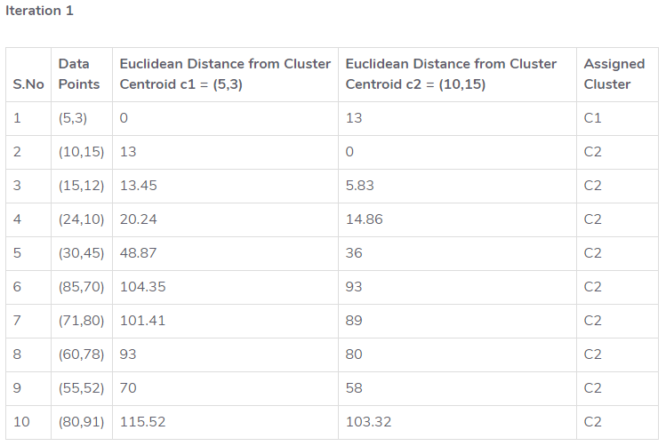

After assigning data points to the corresponding clusters, the next step is to calculate the new centroid values. These values are calculated by finding the means of the coordinates of the data points that belong to a particular cluster.

For cluster C1, there is currently only one point i.e. (5,3), therefore the mean of the coordinates remain same and the new centroid value for c1 will also be (5,3).

For C2, there are currently 9 data points. We name the coordinates of data points as x and y. The new value for x coordinate of centroid c2 can be calculated by determining the mean of x coordinates of all 9 points that belong to cluster C2 as given below:

c2(x) = (10 + 15 + 24 + 30 + 85 + 71 + 60 + 55 + 80) / 9 = 47.77  
The new value for y coordinate of centroid c2 can be calculated by determining the mean of all y coordinates of all 9 points that belong to cluster C2.

c2(y) = (15 + 12 + 10 + 45 + 70 + 80 + 78 + 52 + 91) / 9 = 50.33

**The updated centroid value for c2 will now be {47.77, 50.33}.

For the next iteration, the new centroid values for c1 and c2 will be used and the whole process will be repeated. The iterations continue until the centroid values stop updating.

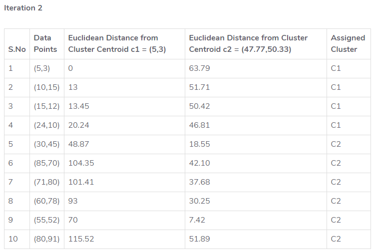

c1(x) = (5, 10, 15, 24) / 4 = 13.5  
c1(y) = (3, 15, 12, 10) / 4 = 10.0 **Updated c1 to be (13.5, 10.0).

c2(x) = (30 + 85 + 71 + 60 + 55 + 80) / 6 = 63.5  
c2(y) = (45 + 70 + 80 + 78 + 52 +91) / 6 = 69.33  
**Updated c2 to be (63.5, 69.33).

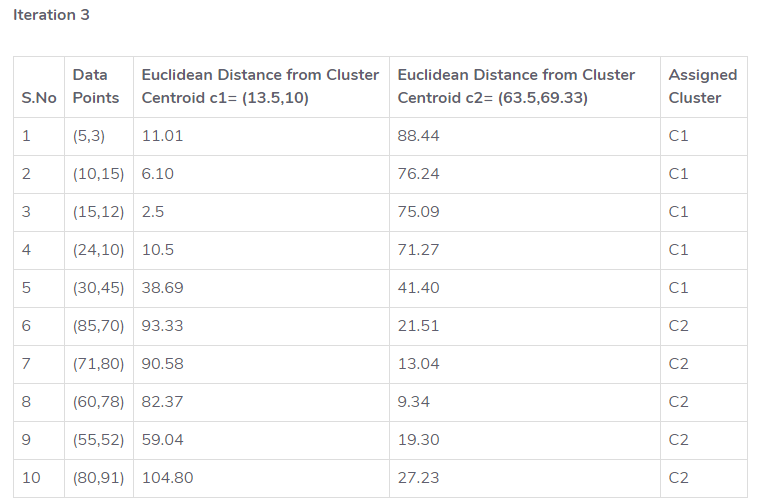

c1(x) = (5, 10, 15, 24, 30) / 5 = 16.8  
c1(y) = (3, 15, 12, 10, 45) / 5 = 17.0  
**Updated c1 to be (16.8, 17.0).

c2(x) = (85 + 71 + 60 + 55 + 80) / 5 = 70.2  
c2(y) = (70 + 80 + 78 + 52 + 91) / 5 = 74.2  
**Updated c2 to be (70.2, 74.2).

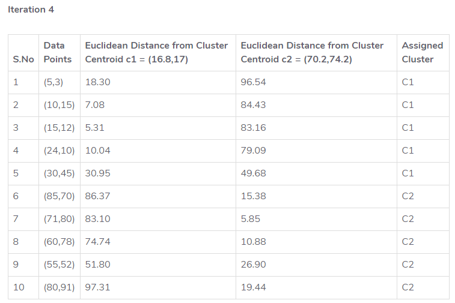

At the end of fourth iteration, the updated values of C1 and C2 are same as they were at the end of the third iteration. This means that data cannot be clustered any further. c1 and c2 are the centroids for C1 and C2. To classify a new data point, the distance between the data point and the centroids of the clusters is calculated. Data point is assigned to the cluster whose centroid is closest to the data point.

## K-means Clustering with Scikit-Learn

Now that we know how the K-means clustering algorithm actually works, let's see how we can implement it with Scikit-Learn.

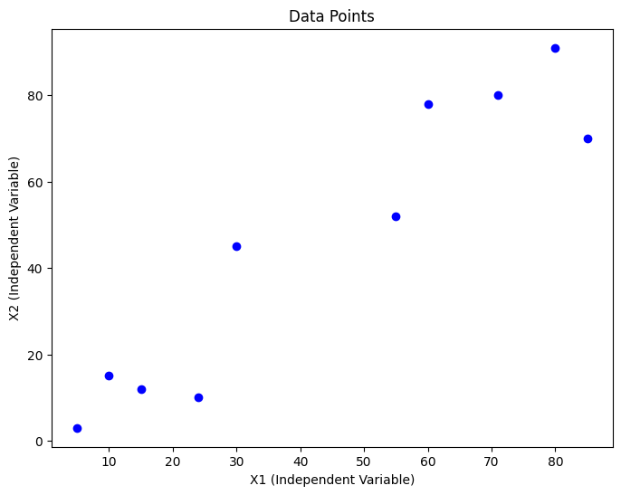

```python
import matplotlib.pyplot as plt
%matplotlib inline
import numpy as np

# prepare the data that we want to cluster
X = np.array([
     [5,  3],
     [10,15],
     [15,12],
     [24,10],
     [30,45],
     [85,70],
     [71,80],
     [60,78],
     [55,52],
     [80,91],])

# Visualize the Data using scatter plot
plt.figure(figsize=(8, 6))
plt.scatter(X[:,0],X[:,1], color='blue', marker='o')
plt.title('Data Points')
plt.xlabel('X1 (Independent Variable)')
plt.ylabel('X2 (Independent Variable)')
plt.show()
```

```python
# https://scikit-learn.org/stable/modules/generated/sklearn.cluster.KMeans.html

# class sklearn.cluster.KMeans(n_clusters=8, *, init='k-means++', n_init='auto', max_iter=300, tol=0.0001, verbose=0, random_state=None, copy_x=True, algorithm='lloyd')

from sklearn.cluster import KMeans
```

```python
# Create Clusters. Assume with no. of clusters = 2
kmeans = KMeans(n_clusters=2, random_state=0)
kmeans.fit(X)
```

```
KMeans(n_clusters=2, random_state=0)
```

```python
# see what centroid values the algorithm generated for the final clusters
print(kmeans.cluster_centers_)
```

```
[[70.2 74.2]
 [16.8 17. ]]
```

```python
# To see the labels for the data point, -> use labels_ attribute
print(kmeans.labels_)


# The output is a one dimensional array of 10 elements corresponding
# to the clusters assigned to our 10 data points.
```

```
[1 1 1 1 1 0 0 0 0 0]
```

Here the first five points have been clustered together and the last five points have been clustered. Here 0 and 1 are merely used to represent cluster IDs and have no mathematical significance.

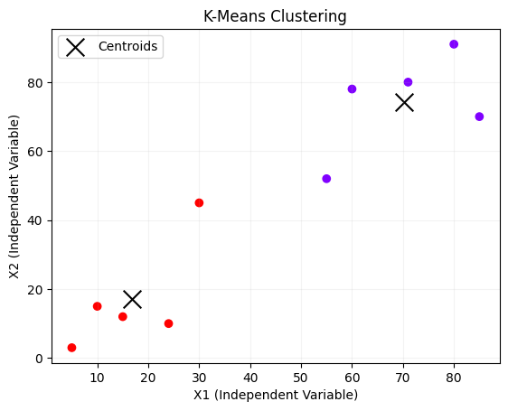

```python
# Let's plot the data points again on the graph and
# visualize how the data has been clustered.

plt.scatter(X[:,0],X[:,1], c=kmeans.labels_, cmap='rainbow')
plt.scatter(kmeans.cluster_centers_[:,0] ,kmeans.cluster_centers_[:,1], color='black', marker='x', s=200, label='Centroids')
plt.title('K-Means Clustering')
plt.xlabel('X1 (Independent Variable)')
plt.ylabel('X2 (Independent Variable)')
plt.legend()
plt.grid(alpha=0.15)
plt.show()
```

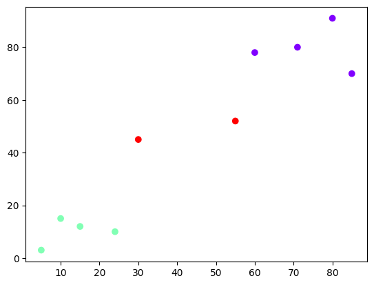

```python
# execute K-means algorithm with three clusters and see the output graph
kmeans = KMeans(n_clusters=3, random_state=0)
kmeans.fit(X)

plt.scatter(X[:,0],X[:,1], c=kmeans.labels_, cmap='rainbow')
```

```python
kmeans.cluster_centers_
```

```
array([[74.  , 79.75],
       [13.5 , 10.  ],
       [42.5 , 48.5 ]])
```

```python
kmeans.labels_
```

```
array([1, 1, 1, 1, 2, 0, 0, 0, 2, 0], dtype=int32)
```

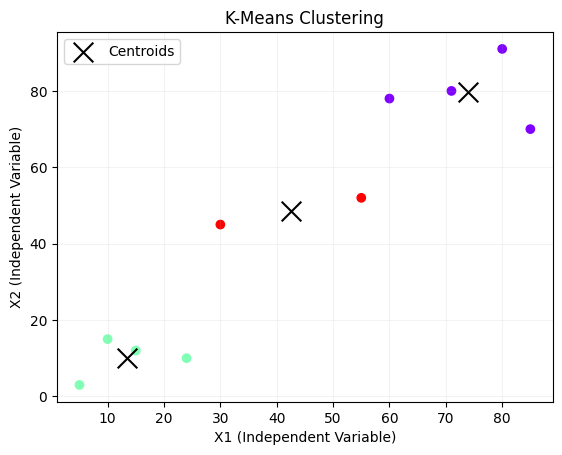

```python
# Let's plot the data points again on the graph and
# visualize how the data has been clustered.

plt.scatter(X[:,0],X[:,1], c=kmeans.labels_, cmap='rainbow')
plt.scatter(kmeans.cluster_centers_[:,0] ,kmeans.cluster_centers_[:,1], color='black', marker='x', s=200, label='Centroids')
plt.title('K-Means Clustering')
plt.xlabel('X1 (Independent Variable)')
plt.ylabel('X2 (Independent Variable)')
plt.legend()
plt.grid(alpha=0.15)
plt.show()
```

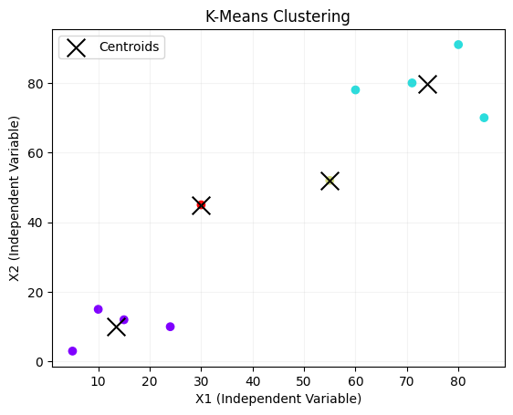

```python
# execute K-means algorithm with three clusters and see the output graph
kmeans = KMeans(n_clusters=4, random_state=0)
kmeans.fit(X)

# Let's plot the data points again on the graph and
# visualize how the data has been clustered.
plt.scatter(X[:,0],X[:,1], c=kmeans.labels_, cmap='rainbow')
plt.scatter(kmeans.cluster_centers_[:,0] ,kmeans.cluster_centers_[:,1], color='black', marker='x', s=200, label='Centroids')
plt.title('K-Means Clustering')
plt.xlabel('X1 (Independent Variable)')
plt.ylabel('X2 (Independent Variable)')
plt.legend()
plt.grid(alpha=0.15)
plt.show()
```

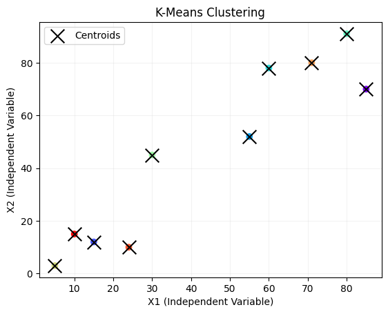

```python
# execute K-means algorithm with three clusters and see the output graph
kmeans = KMeans(n_clusters=10, random_state=0)
kmeans.fit(X)

# Let's plot the data points again on the graph and
# visualize how the data has been clustered.
plt.scatter(X[:,0],X[:,1], c=kmeans.labels_, cmap='rainbow')
plt.scatter(kmeans.cluster_centers_[:,0] ,kmeans.cluster_centers_[:,1], color='black', marker='x', s=200, label='Centroids')
plt.title('K-Means Clustering')
plt.xlabel('X1 (Independent Variable)')
plt.ylabel('X2 (Independent Variable)')
plt.legend()
plt.grid(alpha=0.15)
plt.show()
```

```python
# ValueError: n_samples=10 should be >= n_clusters=11.

# # execute K-means algorithm with three clusters and see the output graph
# kmeans = KMeans(n_clusters=11, random_state=0)
# kmeans.fit(X)

# # Let's plot the data points again on the graph and
# # visualize how the data has been clustered.
# plt.scatter(X[:,0],X[:,1], c=kmeans.labels_, cmap='rainbow')
# plt.scatter(kmeans.cluster_centers_[:,0] ,kmeans.cluster_centers_[:,1], color='black', marker='x', s=200, label='Centroids')
# plt.title('K-Means Clustering')
# plt.xlabel('X1 (Independent Variable)')
# plt.ylabel('X2 (Independent Variable)')
# plt.legend()
# plt.grid(alpha=0.15)
# plt.show()
```

[output not shown]

## Clustering with Gaussian Mixture Models

Clustering is an essential part of any data analysis. Using an algorithm such as K-Means leads to hard assignments, meaning that each point is definitively assigned a cluster center. This leads to some interesting problems: what if the true clusters actually overlap? What about data that is more spread out; how do we assign clusters then?

For further reading of concepts related to Expectation-Maximization Algorithm and GMM, please see this blog article. https://pythonmachinelearning.pro/clustering-with-gaussian-mixture-models/

```python
# Advantages of K-Means Clustering
# 1. Simplicity: K-Means is easy to understand and implement.
# 2. Scalability: It can efficiently handle large datasets.
# 3. Speed: K-Means converges quickly, making it suitable for real-time applications.
# 4. Versatility: It can be used for various types of data and applications.

# Applications of K-Means Clustering
# 1. Customer Segmentation: Grouping customers based on purchasing behavior.
# 2. Image Compression: Reducing the number of colors in an image.
# 3. Anomaly Detection: Identifying unusual patterns in data.
# 4. Market Basket Analysis: Finding associations between products in transactions.
# 5. Document Clustering: Grouping similar documents for information retrieval.
# 6. Recommendation Systems: Suggesting products based on user preferences.
# 7. Social Network Analysis: Identifying communities within social networks.
# 8. Bioinformatics: Clustering genes or proteins based on expression patterns.
# 9. Geospatial Analysis: Grouping geographical locations based on features.
# 10. Fraud Detection: Identifying fraudulent transactions by clustering normal behavior.
# 11. Text Mining: Clustering similar text documents for topic modeling.

# Limitations of K-Means Clustering
# 1. Number of Clusters: The user must specify the number of clusters (k), which can be challenging.
# 2. Sensitivity to Initialization: The algorithm can converge to different solutions based on the initial centroids.
# 3. Assumes Spherical Clusters: K-Means assumes clusters are spherical and equally sized, which may not hold true in real-world data.
# 4. Sensitive to Outliers: Outliers can significantly affect the cluster centroids and lead to poor clustering results.
# 5. Non-Convex Clusters: K-Means struggles with non-convex clusters, as it tends to partition data into convex shapes.
# 6. Requires Numerical Data: K-Means works best with numerical data and may not perform well with categorical or mixed data types.
# 7. Convergence Issues: The algorithm may converge to a local minimum, leading to suboptimal clustering results.
# 8. Scalability: While K-Means is efficient for large datasets, it may still struggle with very high-dimensional data due to the curse of dimensionality.
# 9. Interpretability: The resulting clusters may not always be easily interpretable, especially in high-dimensional spaces.
```